# Módulo de estatística

## Projeto A - Análise do dataset "Wine Quality"

## Turma 782

Alexandre Rozante  
Bruno do Carmo Beraldo Pereira  
Leandro Vieira de Souza

## Ricardo dos Santos Tagliaverga

### Instruções

- O projeto deverá ser entregue até dia 22/11 antes do início da aula
- O projeto poderá ser feito em grupo com até 4 integrantes
- Serão 2 projetos A e B porém apenas 1 projeto deverá ser entregue e escolhido pelo grupo
- A entrega deve ser feita em jupyter notebook com os códigos explícitos e comentados. Além disso os conceitos, decisões e conclusões usadas devem estar destacadas no notebook

### Informações sobre o projeto

Dataset (conjunto de dados a ser utilizado) está disponível em: https://archive.ics.uci.edu/ml/datasets/Wine+Quality

Data Set Information:

The two datasets are related to red and white variants of the Portuguese "Vinho Verde" wine. For more details, consult: [Web Link] or the reference [Cortez et al., 2009]. Due to privacy and logistic issues, only physicochemical (inputs) and sensory (the output) variables are available (e.g. there is no data about grape types, wine brand, wine selling price, etc.).

These datasets can be viewed as classification or regression tasks. The classes are ordered and not balanced (e.g. there are many more normal wines than excellent or poor ones). Outlier detection algorithms could be used to detect the few excellent or poor wines. Also, we are not sure if all input variables are relevant. So it could be interesting to test feature selection methods.

Attribute Information:

Input variables (based on physicochemical tests):

- 1 - fixed acidity
- 2 - volatile acidity
- 3 - citric acid
- 4 - residual sugar
- 5 - chlorides
- 6 - free sulfur dioxide
- 7 - total sulfur dioxide
- 8 - density
- 9 - pH
- 10 - sulphates
- 11 - alcohol

Output variable (based on sensory data):

- 12 - quality (score between 0 and 10)

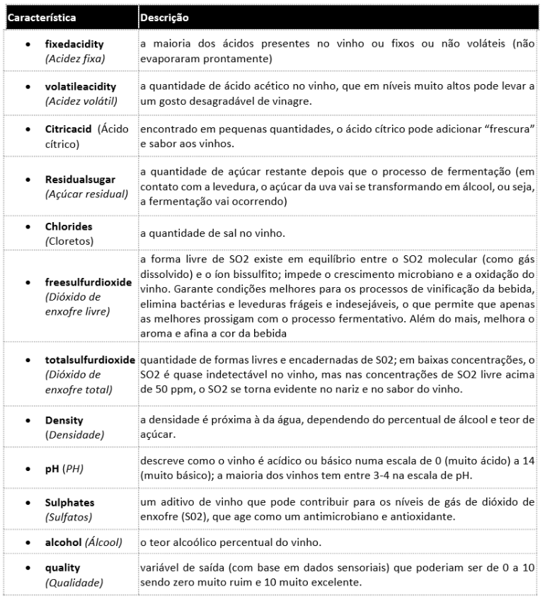

### Etapa 1

**EDA - Análise exploratória de dados**

- Análise das medidas de posição, dispersão, correlação (análises univaridas e bivariadas) - histograma, boxplot, mapa de calor, etc...
- Exclusão de outliers, caso necessário (sempre explicando a opção)

### Etapa 2

**Regressão Linear**

- Faça um algoritmo que estime a variável “Quality” em função das características físico-químicas dos vinhos
- Colocar comentários sobre a técnica utilizada e análise sobre as variáveis utilizadas, além dos seus respectivos “achados”. Faça uma interpretação do resultado

### Etapa 3

**Regressão logística**

- Sabendo que os vinhos com notas >= 6 são considerados vinhos de boa qualidade faça um algoritmo que classifique os vinhos em “Bom” ou “Ruim” em função de suas características físico-químicas;
- Colocar comentários sobre a técnica utilizada e análise sobre as variáveis utilizadas, além dos seus respectivos “achados”. Faça uma interpretação do resultado

# Etapa 1 - EDA

```python
# Bibliotecas utilizadas
import numpy as np
import pandas as pd

import matplotlib.pyplot as plt
from matplotlib import cm
import plotly.graph_objects as go
from plotly.subplots import make_subplots
import seaborn as sns

from sklearn.linear_model import LinearRegression, LogisticRegression
from sklearn.metrics import mean_squared_error, r2_score
from sklearn.metrics import confusion_matrix, accuracy_score, f1_score, precision_score, recall_score
from sklearn.model_selection import train_test_split
from sklearn.preprocessing import StandardScaler
```

```python
# Carregamento dos dados
tintos  = pd.read_csv("winequality-red.csv", delimiter=";")
brancos = pd.read_csv("winequality-white.csv", delimiter=";")
```

```python
# Entendimento das colunas dos datasets
display(tintos.head(3))
display(brancos.head(3))
display(brancos.info())
```

|  | fixed acidity | volatile acidity | citric acid | residual sugar | chlorides | free sulfur dioxide | total sulfur dioxide | density | pH | sulphates | alcohol | quality |
| --- | --- | --- | --- | --- | --- | --- | --- | --- | --- | --- | --- | --- |
| 0 | 7.4 | 0.70 | 0.00 | 1.9 | 0.076 | 11.0 | 34.0 | 0.9978 | 3.51 | 0.56 | 9.4 | 5 |
| 1 | 7.8 | 0.88 | 0.00 | 2.6 | 0.098 | 25.0 | 67.0 | 0.9968 | 3.20 | 0.68 | 9.8 | 5 |
| 2 | 7.8 | 0.76 | 0.04 | 2.3 | 0.092 | 15.0 | 54.0 | 0.9970 | 3.26 | 0.65 | 9.8 | 5 |

|  | fixed acidity | volatile acidity | citric acid | residual sugar | chlorides | free sulfur dioxide | total sulfur dioxide | density | pH | sulphates | alcohol | quality |
| --- | --- | --- | --- | --- | --- | --- | --- | --- | --- | --- | --- | --- |
| 0 | 7.0 | 0.27 | 0.36 | 20.7 | 0.045 | 45.0 | 170.0 | 1.0010 | 3.00 | 0.45 | 8.8 | 6 |
| 1 | 6.3 | 0.30 | 0.34 | 1.6 | 0.049 | 14.0 | 132.0 | 0.9940 | 3.30 | 0.49 | 9.5 | 6 |
| 2 | 8.1 | 0.28 | 0.40 | 6.9 | 0.050 | 30.0 | 97.0 | 0.9951 | 3.26 | 0.44 | 10.1 | 6 |

```
<class 'pandas.core.frame.DataFrame'>
RangeIndex: 4898 entries, 0 to 4897
Data columns (total 12 columns):
 #   Column                Non-Null Count  Dtype
---  ------                --------------  -----
 0   fixed acidity         4898 non-null   float64
 1   volatile acidity      4898 non-null   float64
 2   citric acid           4898 non-null   float64
 3   residual sugar        4898 non-null   float64
 4   chlorides             4898 non-null   float64
 5   free sulfur dioxide   4898 non-null   float64
 6   total sulfur dioxide  4898 non-null   float64
 7   density               4898 non-null   float64
 8   pH                    4898 non-null   float64
 9   sulphates             4898 non-null   float64
 10  alcohol               4898 non-null   float64
 11  quality               4898 non-null   int64
dtypes: float64(11), int64(1)
memory usage: 459.3 KB
```

```
None
```

### Conclusões:

Temos 11 variáveis quantitativas contínuas e uma variável qualitativa discreta (variável alvo = "quality").  
Os dois *datasets* possuem mesma estrutura e tipos de dados.

```python
# Avaliação de dados faltantes
print('Análise de valores faltantes - vinhos tintos:')
display(tintos.dropna().count())
print('Análise de valores faltantes - vinhos brancos:')
display(brancos.dropna().count())
```

```
Análise de valores faltantes - vinhos tintos:
```

```
fixed acidity           1599
volatile acidity        1599
citric acid             1599
residual sugar          1599
chlorides               1599
free sulfur dioxide     1599
total sulfur dioxide    1599
density                 1599
pH                      1599
sulphates               1599
alcohol                 1599
quality                 1599
dtype: int64
```

```
Análise de valores faltantes - vinhos brancos:
```

```
fixed acidity           4898
volatile acidity        4898
citric acid             4898
residual sugar          4898
chlorides               4898
free sulfur dioxide     4898
total sulfur dioxide    4898
density                 4898
pH                      4898
sulphates               4898
alcohol                 4898
quality                 4898
dtype: int64
```

### Avaliação:

Não temos valores faltantes em nenhum dos *datasets*. Podemos prosseguir com as avaliações como eles estão.

```python
# Criando um dataset unificado com uma coluna 'type' identificando o tipo de vinho
tmp_tintos = tintos.copy()
tmp_tintos['type'] = 'red'
tmp_brancos = brancos.copy()
tmp_brancos['type'] = 'white'
vinhos = pd.concat([tmp_tintos, tmp_brancos])
tmp_tintos = None
tmp_brancos = None
vinhos.sample(10)
```

|  | fixed acidity | volatile acidity | citric acid | residual sugar | chlorides | free sulfur dioxide | total sulfur dioxide | density | pH | sulphates | alcohol | quality | type |
| --- | --- | --- | --- | --- | --- | --- | --- | --- | --- | --- | --- | --- | --- |
| 356 | 11.5 | 0.41 | 0.52 | 3.0 | 0.080 | 29.0 | 55.0 | 1.00010 | 3.26 | 0.88 | 11.0 | 5 | red |
| 1224 | 7.2 | 0.23 | 0.39 | 2.3 | 0.033 | 29.0 | 102.0 | 0.99080 | 3.26 | 0.54 | 12.3 | 7 | white |
| 4296 | 6.9 | 0.22 | 0.32 | 5.8 | 0.041 | 20.0 | 119.0 | 0.99296 | 3.17 | 0.55 | 11.2 | 6 | white |
| 252 | 11.1 | 0.35 | 0.48 | 3.1 | 0.090 | 5.0 | 21.0 | 0.99860 | 3.17 | 0.53 | 10.5 | 5 | red |
| 4861 | 5.5 | 0.31 | 0.29 | 3.0 | 0.027 | 16.0 | 102.0 | 0.99067 | 3.23 | 0.56 | 11.2 | 6 | white |
| 83 | 7.3 | 0.67 | 0.26 | 1.8 | 0.401 | 16.0 | 51.0 | 0.99690 | 3.16 | 1.14 | 9.4 | 5 | red |
| 9 | 8.1 | 0.22 | 0.43 | 1.5 | 0.044 | 28.0 | 129.0 | 0.99380 | 3.22 | 0.45 | 11.0 | 6 | white |
| 284 | 9.9 | 0.59 | 0.07 | 3.4 | 0.102 | 32.0 | 71.0 | 1.00015 | 3.31 | 0.71 | 9.8 | 5 | red |
| 108 | 8.0 | 0.33 | 0.53 | 2.5 | 0.091 | 18.0 | 80.0 | 0.99760 | 3.37 | 0.80 | 9.6 | 6 | red |
| 453 | 6.0 | 0.27 | 0.27 | 1.6 | 0.046 | 32.0 | 113.0 | 0.99240 | 3.41 | 0.51 | 10.5 | 7 | white |

```python
# Entendimento dos valores mínimo e máximo da variável-alvo por tipo de vinho
tmp = vinhos.groupby('type')
display(pd.concat([tmp['quality'].min(), tmp['quality'].max()]))
tmp = None
```

```
type
red      3
white    3
red      8
white    9
Name: quality, dtype: int64
```

### Avaliação:

Embora os vinhos possam receber avaliações entre 1 e 10, de fato estão distribuídos em menos categorias, conforme acima.

```python
# Entendimento da distribuição da população de vinhos tintos
tintos.groupby('quality')['quality'].count()
```

```
quality
3     10
4     53
5    681
6    638
7    199
8     18
Name: quality, dtype: int64
```

```python
# Entendimento da distribuição da população de vinhos brancos
brancos.groupby('quality')['quality'].count()
```

```
quality
3      20
4     163
5    1457
6    2198
7     880
8     175
9       5
Name: quality, dtype: int64
```

### Avaliação

Temos concentração de amostragem nos vinhos intermediários (qualidades 5, 6 e 7). Logo, é necessária atenção na eventual remoção de outliers para os vinhos das qualidades de extremidade.

## Medidas de posição e dispersão

```python
tintos_desc = tintos.describe().T.copy()
tintos_desc['iqr']  = tintos_desc['75%'] - tintos_desc['25%']
tintos_desc['ampl'] = tintos_desc['max'] - tintos_desc['min']
tintos_desc = tintos_desc.join(tintos.mode().T)
tintos_desc.rename({0:'mode'}, axis=1, inplace=True)
tintos_desc['var']  = tintos_desc['std'] ** 2
tintos_desc = tintos_desc.join(pd.DataFrame(tintos.skew()))
tintos_desc.rename({0:'skew'}, axis=1, inplace=True)
tintos_desc
```

|  | count | mean | std | min | 25% | 50% | 75% | max | iqr | ampl | mode | var | skew |
| --- | --- | --- | --- | --- | --- | --- | --- | --- | --- | --- | --- | --- | --- |
| fixed acidity | 1599.0 | 8.319637 | 1.741096 | 4.60000 | 7.1000 | 7.90000 | 9.200000 | 15.90000 | 2.100000 | 11.30000 | 7.2000 | 3.031416 | 0.982751 |
| volatile acidity | 1599.0 | 0.527821 | 0.179060 | 0.12000 | 0.3900 | 0.52000 | 0.640000 | 1.58000 | 0.250000 | 1.46000 | 0.6000 | 0.032062 | 0.671593 |
| citric acid | 1599.0 | 0.270976 | 0.194801 | 0.00000 | 0.0900 | 0.26000 | 0.420000 | 1.00000 | 0.330000 | 1.00000 | 0.0000 | 0.037947 | 0.318337 |
| residual sugar | 1599.0 | 2.538806 | 1.409928 | 0.90000 | 1.9000 | 2.20000 | 2.600000 | 15.50000 | 0.700000 | 14.60000 | 2.0000 | 1.987897 | 4.540655 |
| chlorides | 1599.0 | 0.087467 | 0.047065 | 0.01200 | 0.0700 | 0.07900 | 0.090000 | 0.61100 | 0.020000 | 0.59900 | 0.0800 | 0.002215 | 5.680347 |
| free sulfur dioxide | 1599.0 | 15.874922 | 10.460157 | 1.00000 | 7.0000 | 14.00000 | 21.000000 | 72.00000 | 14.000000 | 71.00000 | 6.0000 | 109.414884 | 1.250567 |
| total sulfur dioxide | 1599.0 | 46.467792 | 32.895324 | 6.00000 | 22.0000 | 38.00000 | 62.000000 | 289.00000 | 40.000000 | 283.00000 | 28.0000 | 1082.102373 | 1.515531 |
| density | 1599.0 | 0.996747 | 0.001887 | 0.99007 | 0.9956 | 0.99675 | 0.997835 | 1.00369 | 0.002235 | 0.01362 | 0.9972 | 0.000004 | 0.071288 |
| pH | 1599.0 | 3.311113 | 0.154386 | 2.74000 | 3.2100 | 3.31000 | 3.400000 | 4.01000 | 0.190000 | 1.27000 | 3.3000 | 0.023835 | 0.193683 |
| sulphates | 1599.0 | 0.658149 | 0.169507 | 0.33000 | 0.5500 | 0.62000 | 0.730000 | 2.00000 | 0.180000 | 1.67000 | 0.6000 | 0.028733 | 2.428672 |
| alcohol | 1599.0 | 10.422983 | 1.065668 | 8.40000 | 9.5000 | 10.20000 | 11.100000 | 14.90000 | 1.600000 | 6.50000 | 9.5000 | 1.135647 | 0.860829 |
| quality | 1599.0 | 5.636023 | 0.807569 | 3.00000 | 5.0000 | 6.00000 | 6.000000 | 8.00000 | 1.000000 | 5.00000 | 5.0000 | 0.652168 | 0.217802 |

```python
brancos_desc = brancos.describe().T.copy()
brancos_desc['iqr']  = brancos_desc['75%'] - brancos_desc['25%']
brancos_desc['ampl'] = brancos_desc['max'] - brancos_desc['min']
brancos_desc = brancos_desc.join(brancos.mode().T)
brancos_desc.rename({0:'mode'}, axis=1, inplace=True)
brancos_desc['var']  = brancos_desc['std'] ** 2
brancos_desc = brancos_desc.join(pd.DataFrame(brancos.skew()))
brancos_desc.rename({0:'skew'}, axis=1, inplace=True)
brancos_desc
```

|  | count | mean | std | min | 25% | 50% | 75% | max | iqr | ampl | mode | var | skew |
| --- | --- | --- | --- | --- | --- | --- | --- | --- | --- | --- | --- | --- | --- |
| fixed acidity | 4898.0 | 6.854788 | 0.843868 | 3.80000 | 6.300000 | 6.80000 | 7.3000 | 14.20000 | 1.000000 | 10.40000 | 6.800 | 0.712114 | 0.647751 |
| volatile acidity | 4898.0 | 0.278241 | 0.100795 | 0.08000 | 0.210000 | 0.26000 | 0.3200 | 1.10000 | 0.110000 | 1.02000 | 0.280 | 0.010160 | 1.576980 |
| citric acid | 4898.0 | 0.334192 | 0.121020 | 0.00000 | 0.270000 | 0.32000 | 0.3900 | 1.66000 | 0.120000 | 1.66000 | 0.300 | 0.014646 | 1.281920 |
| residual sugar | 4898.0 | 6.391415 | 5.072058 | 0.60000 | 1.700000 | 5.20000 | 9.9000 | 65.80000 | 8.200000 | 65.20000 | 1.200 | 25.725770 | 1.077094 |
| chlorides | 4898.0 | 0.045772 | 0.021848 | 0.00900 | 0.036000 | 0.04300 | 0.0500 | 0.34600 | 0.014000 | 0.33700 | 0.044 | 0.000477 | 5.023331 |
| free sulfur dioxide | 4898.0 | 35.308085 | 17.007137 | 2.00000 | 23.000000 | 34.00000 | 46.0000 | 289.00000 | 23.000000 | 287.00000 | 29.000 | 289.242720 | 1.406745 |
| total sulfur dioxide | 4898.0 | 138.360657 | 42.498065 | 9.00000 | 108.000000 | 134.00000 | 167.0000 | 440.00000 | 59.000000 | 431.00000 | 111.000 | 1806.085491 | 0.390710 |
| density | 4898.0 | 0.994027 | 0.002991 | 0.98711 | 0.991723 | 0.99374 | 0.9961 | 1.03898 | 0.004377 | 0.05187 | 0.992 | 0.000009 | 0.977773 |
| pH | 4898.0 | 3.188267 | 0.151001 | 2.72000 | 3.090000 | 3.18000 | 3.2800 | 3.82000 | 0.190000 | 1.10000 | 3.140 | 0.022801 | 0.457783 |
| sulphates | 4898.0 | 0.489847 | 0.114126 | 0.22000 | 0.410000 | 0.47000 | 0.5500 | 1.08000 | 0.140000 | 0.86000 | 0.500 | 0.013025 | 0.977194 |
| alcohol | 4898.0 | 10.514267 | 1.230621 | 8.00000 | 9.500000 | 10.40000 | 11.4000 | 14.20000 | 1.900000 | 6.20000 | 9.400 | 1.514427 | 0.487342 |
| quality | 4898.0 | 5.877909 | 0.885639 | 3.00000 | 5.000000 | 6.00000 | 6.0000 | 9.00000 | 1.000000 | 6.00000 | 6.000 | 0.784356 | 0.155796 |

### Avaliação

Temos variáveis com baixa variância (exemplo: "density") e alta variância (exemplos: "free sulfur dioxide" e "total sulfur dioxide").  
Algumas variáveis parecem seguir a distribuição normal, enquanto outras claramente não, algo importante na análise de *outliers*.

## Análise de outliers

Considerando as diferenças de características das variáveis e o desbalanceamento das amostras em relação à qualidade, consideramos que uma análise de *outliers* deve ser realizada levando em conta o tipo de vinho e a qualidade.

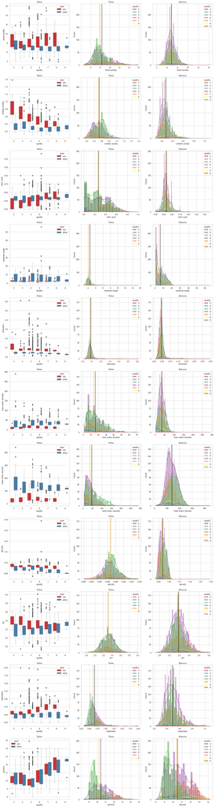

```python
# Plotagem dos Boxplot e Histogramas separando os tinhos de vinho e diferentes qualidades

import warnings
warnings.filterwarnings("ignore")

sns.set_theme()
sns.set_style('whitegrid')
pal = 'Set1'
fig, axs=plt.subplots(11, 3, figsize=(20, 80))
r = 0
for col in vinhos.columns[0:-2]:   # As variáveis 'quality' e 'type' não entram como dados explicativos
    # Boxplot
    b = sns.boxplot(data=vinhos, x='quality', y=col, hue='type', palette=pal, linewidth=0.5, ax=axs[r,0])
    b.set_title('Todos')

    # Histograma vinhos tintos
    f = sns.histplot(data=tintos, x=col, hue='quality', kde=True, palette=pal, ax=axs[r,1])
    f.axvline(tintos[col].mean(), color='black', label='Média')
    f.axvline(tintos[col].median(), color='orange', label='Mediana')
    f.set_title('Tintos')

    # Histograma vinhos brancos
    g = sns.histplot(data=brancos, x=col, hue='quality', kde=True, palette=pal, ax=axs[r,2])
    g.axvline(brancos[col].mean(), color='black', label='Média')
    g.axvline(brancos[col].median(), color='orange', label='Mediana')
    g.set_title('Brancos')

    # Equaliza o eixo Y dos histogramas pelo que possui maior amplitude
    fmax = f.get_ylim()[1]
    gmax = g.get_ylim()[1]
    if (fmax > gmax):
        g.set_ylim(f.get_ylim())
    else:
        f.set_ylim(g.get_ylim())
    r += 1
plt.show()
```

## Avaliação

**Fixed acidity:** Temos claramente *outliers* em praticamente todas as qualidades de vinho. Contudo, há somente 5 vinhos brancos de qualidade 9, e remover apenas um vinho que se apresenta como *outlier* para essa variável não é indicado (remoção de 20% da amostra).

**Volatile acidity:** Uma avaliação quantitativa dos vinhos brancos qualidades 5 e 6 é necessária para avaliar os *outliers*.

**Citric acid:** Uma avaliação quantitativa dos vinhos brancos qualidades 5, 6 e 7 é necessária para avaliar os *outliers*.

**Residual sugar:** Para os vinhos tintos a amplitude dessa variável é tão baixa que os *outliers* paracem não ser realmente *outliers*. Uma avaliação matemática complementar é necessária antes de prosseguir com a remoção.  
Para os vinhos brancos de qualidade 9 não removeremos *outliers*, devido ser uma amostragem muito reduzida.

**Chlorides:** Aparentemente temos a presença de muitos *outliers* para ambos tipos de vinho. Uma avaliação sobre a proporção desses *outliers* em relação ao tamanho das amostras por qualidade é necessária.

**Free sulfur dioxide:** Aparentemente podemos remover os *outliers*, mas desconsiderando os vinhos tintos qualidade 3 e vinhos brancos qualidade 9, devido ao tamanho reduzido dessas amostragens.

**Total sulfur dioxide:** Aparentemente podemos remover os *outliers*, mas desconsiderando os vinhos brancos qualidade 9, devido ao tamanho reduzido dessa amostragem.

**Density:** Antes de remover os *outliers*, devemos avaliar matematicamente os vinhos tintos qualidade 5 e 6. Ainda, manteremos os vinhos brancos qualidade 9 devido o tamanho reduzido dessa amostragem.

**pH:** Podemos remover os outliers.

**Sulphates:** Cabe avaliar se realmente vamos remover todos os *outliers*, com exceção dos brancos qualidade 9 pelo motivo já citado algumas vezes aqui.

**Alcohol:** Cabe apenas preservar os vinhos brancos qualidade 9, dado o reduzido tamanho dessa amostra.

### Avaliação matemática complementar

*Necessária para definir se realmente temos outliers para algumas variáveis.*

```python
# Calcula os valores dos whiskers superior e inferior para uma data variável do DataFrame,
# pelo fator de multiplicação de IQR especificado
def whiskers(data, col, qual, fator):
    tmp = data.loc[data['quality'] == qual]
    q1 = tmp[col].quantile(0.25)
    q3 = tmp[col].quantile(0.75)
    iqr = q3 - q1
    winf = q1 - iqr * fator
    wsup = q3 + iqr * fator
    return winf, wsup

# Retorna a quantidade total, quantidade de outliers e o percentual de outliers para uma data variável de um DataFrame
# com o fator de multiplicação de IQR especificado (padrão = 1.5)
def qtd_outliers(data, col, qual, fator=1.5):
    winf, wsup = whiskers(data, col, qual, fator)
    qt = data.loc[data['quality'] == qual][col].size
    qo = data.loc[(data['quality'] == qual) & ((data[col] < winf) | (data[col] > wsup))][col].size
    qp = 0.0 if qo == 0 else round(qo / float(qt) * 100, 2)
    return qt, qo, qp

# Imprime os resultados para todas as variáveis explicativas do DataFrame de vinhos tintos
print('Tintos')
print('Variavel' + ' ' * 18, 'QTot Qout Percent')
for col in tintos.columns[:-1]:
    for qual in range(3,10):
        qt, qo, qp = qtd_outliers(tintos, col, qual)
        print('{}) {}: {:4} {:4} {}%'.format(qual, col + ' ' * (22 - len(col)), qt, qo, qp))
    print()

# Imprime os resultados para todas as variáveis explicativas do DataFrame de vinhos brancos
print('Brancos')
print('Variavel' + ' ' * 19, 'QTot  Qout Percent')
for col in brancos.columns[:-1]:
    for qual in range(3,10):
        qt, qo, qp = qtd_outliers(brancos, col, qual)
        print('{}) {}: {:5} {:5} {}%'.format(qual, col + ' ' * (22 - len(col)), qt, qo, qp))
    print()
```

```
Tintos
Variavel                   QTot Qout Percent
3) fixed acidity         :   10    0 0.0%
4) fixed acidity         :   53    3 5.66%
5) fixed acidity         :  681   26 3.82%
6) fixed acidity         :  638    9 1.41%
7) fixed acidity         :  199    3 1.51%
8) fixed acidity         :   18    0 0.0%
9) fixed acidity         :    0    0 0.0%

3) volatile acidity      :   10    1 10.0%
4) volatile acidity      :   53    0 0.0%
5) volatile acidity      :  681   10 1.47%
6) volatile acidity      :  638    7 1.1%
7) volatile acidity      :  199    5 2.51%
8) volatile acidity      :   18    1 5.56%
9) volatile acidity      :    0    0 0.0%

3) citric acid           :   10    0 0.0%
4) citric acid           :   53    1 1.89%
5) citric acid           :  681    1 0.15%
6) citric acid           :  638    0 0.0%
7) citric acid           :  199   17 8.54%
8) citric acid           :   18    0 0.0%
9) citric acid           :    0    0 0.0%

3) residual sugar        :   10    1 10.0%
4) residual sugar        :   53    7 13.21%
5) residual sugar        :  681   66 9.69%
6) residual sugar        :  638   53 8.31%
7) residual sugar        :  199   27 13.57%
8) residual sugar        :   18    2 11.11%
9) residual sugar        :    0    0 0.0%

3) chlorides             :   10    1 10.0%
4) chlorides             :   53    4 7.55%
5) chlorides             :  681   43 6.31%
6) chlorides             :  638   49 7.68%
7) chlorides             :  199    6 3.02%
8) chlorides             :   18    0 0.0%
```

[output cut: 124 more lines]

```
3) sulphates             :    20     0 0.0%
4) sulphates             :   163     3 1.84%
5) sulphates             :  1457    56 3.84%
6) sulphates             :  2198    59 2.68%
7) sulphates             :   880    16 1.82%
8) sulphates             :   175     4 2.29%
9) sulphates             :     5     1 20.0%

3) alcohol               :    20     0 0.0%
4) alcohol               :   163     2 1.23%
5) alcohol               :  1457    35 2.4%
6) alcohol               :  2198     0 0.0%
7) alcohol               :   880     0 0.0%
8) alcohol               :   175     1 0.57%
9) alcohol               :     5     1 20.0%
```

### Avaliação

**Fixed acidity:** Confirmada a remoção de todos os *outliers*, exceto vinhos brancos de qualidade 9.

**Volatile acidity:** A quantidade de *outliers* não é significativa. Podemos prosseguir com a remoção.

**Citric acid:** A quantidade de *outliers* não é significativa. Podemos prosseguir com a remoção.

**Residual sugar:** Constatamos que para vinhos tintos, há uma grande quantidade de *outliers* para o fator 1.5 IQR. Para esses, é recomendada a remoção com fator maior. Após algumas explorações, o grupo definiu uso do fator 2.5.  
Para vinhos brancos a remoção com 1.5 IQR é adequada.

**Chlorides:** Ao contrário da primeira impressão, a remoção de *outliers* aqui é adequada com fator 1.5.

**Free sulfur dioxide:** Confirmado que o recomendado aqui é preservar os *outliers* dos vinhos qualidades 3 e 9, podendo remover os demais.

**Total sulfur dioxide:** Confirmado que devemos manter todos os vinhos brancos qualidade 9, e remover os demais.

**Density:** Confirmado que devemos manter todos os vinhos brancos qualidade 9, e remover os demais.

**pH:** Confirmado que podemos remover os *outliers*.

**Sulphates:** Confirmado que devemos manter todos os vinhos brancos qualidade 9, e remover os demais.

**Alcohol:** Confirmado que devemos manter todos os vinhos brancos qualidade 9, e remover os demais.

```python
# Relembrando a ordem das colunas dos DataFrames
tintos.columns
```

```
Index(['fixed acidity', 'volatile acidity', 'citric acid', 'residual sugar',
       'chlorides', 'free sulfur dioxide', 'total sulfur dioxide', 'density',
       'pH', 'sulphates', 'alcohol', 'quality'],
      dtype='object')
```

```python
# Para alcançar o que foi proposto:
# Utilizaremos uma lista de tuplas compostas de:
# 0 = nome da coluna
# 1 = tupla de fatores para vinhos tintos
# 2 = tupla de fatores para vinhos brancos
# Essencial que a lista esteja na mesma ordem de nomes de colunas dos DataFrames
# As tuplas de fatores contém os valores para as qualidades 3 a 9, e se um valor for None, não haverá remoção de outliers.
cfg = [
 ('fixed acidity',        (1.5,  1.5, 1.5, 1.5, 1.5, 1.5, None), (1.5,  1.5, 1.5, 1.5, 1.5, 1.5, None)),
 ('volatile acidity',     (1.5,  1.5, 1.5, 1.5, 1.5, 1.5, None), (1.5,  1.5, 1.5, 1.5, 1.5, 1.5, None)),
 ('citric acid',          (1.5,  1.5, 1.5, 1.5, 1.5, 1.5, None), (1.5,  1.5, 1.5, 1.5, 1.5, 1.5, None)),
 ('residual sugar',       (2.5,  2.5, 2.5, 2.5, 2.5, 2.5, None), (1.5,  1.5, 1.5, 1.5, 1.5, 1.5, None)),
 ('chlorides',            (1.5,  1.5, 1.5, 1.5, 1.5, 1.5, None), (1.5,  1.5, 1.5, 1.5, 1.5, 1.5, None)),
 ('free sulfur dioxide',  (None, 1.5, 1.5, 1.5, 1.5, 1.5, None), (None, 1.5, 1.5, 1.5, 1.5, 1.5, None)),
 ('total sulfur dioxide', (1.5,  1.5, 1.5, 1.5, 1.5, 1.5, None), (1.5,  1.5, 1.5, 1.5, 1.5, 1.5, None)),
 ('density',              (1.5,  1.5, 1.5, 1.5, 1.5, 1.5, None), (1.5,  1.5, 1.5, 1.5, 1.5, 1.5, None)),
 ('pH',                   (1.5,  1.5, 1.5, 1.5, 1.5, 1.5, None), (1.5,  1.5, 1.5, 1.5, 1.5, 1.5, None)),
 ('sulphates',            (1.5,  1.5, 1.5, 1.5, 1.5, 1.5, None), (1.5,  1.5, 1.5, 1.5, 1.5, 1.5, None)),
 ('alcohol',              (1.5,  1.5, 1.5, 1.5, 1.5, 1.5, None), (1.5,  1.5, 1.5, 1.5, 1.5, 1.5, None))
]
```

```python
# Remove outliers de um DataFrame, para a coluna informada, registros com qualidade informada e fator IQR
def rem_outliers(dados, col, qual, fat):
    winf, wsup = whiskers(dados, col, qual, fat)
#    print(col + ':', 'winf:', winf, 'wsup:', wsup)
    dados = dados.drop(dados.loc[(dados['quality'] == qual) & ((dados[col] < winf) | (dados[col] > wsup))].index)
    return dados

# Processa remoções de um DataFrame. Indice = 1 = tintos; Indice = 2 = brancos
def limpar(dados, indices):
    for config in cfg:
        col = config[0]                    # Nome a coluna
        for qual in range(3,10):           # Percorre todas as qualidades de vinho
            fat = config[indices][qual-3]  # Índice IQR para a coluna
            if fat is not None:
                dados = rem_outliers(dados, col, qual, fat)
    return dados
```

```python
print('*** Vinhos Tintos ***')
tintos_so = limpar(tintos.copy(), 1)
```

```
*** Vinhos Tintos ***
```

```python
print('*** Vinhos Brancos ***')
brancos_so = limpar(brancos.copy(), 2)
```

```
*** Vinhos Brancos ***
```

```python
# Cria o DataFrame unificado vinhos_so (vinhos sem outliers) para uso no processo de plotagem
tmp_tintos = tintos_so.copy()
tmp_tintos['type'] = 'red'
tmp_brancos = brancos_so.copy()
tmp_brancos['type'] = 'white'
vinhos_so = pd.concat([tmp_tintos, tmp_brancos])
tmp_tintos = None
tmp_brancos = None
vinhos_so.sample(5)
```

|  | fixed acidity | volatile acidity | citric acid | residual sugar | chlorides | free sulfur dioxide | total sulfur dioxide | density | pH | sulphates | alcohol | quality | type |
| --- | --- | --- | --- | --- | --- | --- | --- | --- | --- | --- | --- | --- | --- |
| 1506 | 6.8 | 0.81 | 0.05 | 2.0 | 0.070 | 6.0 | 14.0 | 0.99562 | 3.51 | 0.66 | 10.8 | 6 | red |
| 720 | 8.4 | 0.56 | 0.04 | 2.0 | 0.082 | 10.0 | 22.0 | 0.99760 | 3.22 | 0.44 | 9.6 | 5 | red |
| 1121 | 6.0 | 0.40 | 0.30 | 1.6 | 0.047 | 30.0 | 117.0 | 0.99310 | 3.17 | 0.48 | 10.1 | 6 | white |
| 4773 | 5.2 | 0.21 | 0.31 | 1.7 | 0.048 | 17.0 | 61.0 | 0.98953 | 3.24 | 0.37 | 12.0 | 7 | white |
| 1085 | 6.8 | 0.48 | 0.08 | 1.8 | 0.074 | 40.0 | 64.0 | 0.99529 | 3.12 | 0.49 | 9.6 | 5 | red |

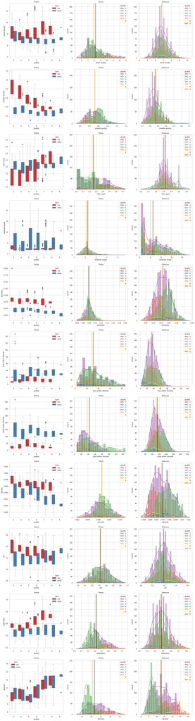

```python
# Plotagem dos Boxplot e Histogramas após remoção de outliers

fig, axs=plt.subplots(11, 3, figsize=(20, 80))
r = 0
for col in vinhos_so.columns[0:-2]:
    b = sns.boxplot(data=vinhos_so, x='quality', y=col, hue='type', palette=pal, linewidth=0.5, ax=axs[r,0])
    b.set_title('Todos')

    f = sns.histplot(data=tintos_so, x=col, hue='quality', kde=True, palette=pal, ax=axs[r,1])
    f.axvline(tintos_so[col].mean(), color='black', label='Média')
    f.axvline(tintos_so[col].median(), color='orange', label='Mediana')
    f.set_title('Tintos')

    g = sns.histplot(data=brancos_so, x=col, hue='quality', kde=True, palette=pal, ax=axs[r,2])
    g.axvline(brancos_so[col].mean(), color='black', label='Média')
    g.axvline(brancos_so[col].median(), color='orange', label='Mediana')
    g.set_title('Brancos')

    fmax = f.get_ylim()[1]
    gmax = g.get_ylim()[1]
    if (fmax > gmax):
        g.set_ylim(f.get_ylim())
    else:
        f.set_ylim(g.get_ylim())
    r += 1
plt.show()
```

### Avaliação

Podemos constatar que a remoção de *outliers* funcionou como esperado.  
Alguns *outliers* foram preservados, como já era previsto. São dados que o grupo considera normais pela dispersão da variável ou *outliers* não removidos devido o tamanho reduzido da amostra para a determinada qualidade de vinho.

## Análise Bivariada

```python
# Plotagem para visualização da correlação entre as variáveis
sns.set_theme()
pallete_colors = ['darkred','yellowgreen']
sns.set_palette(sns.color_palette(pallete_colors))
```

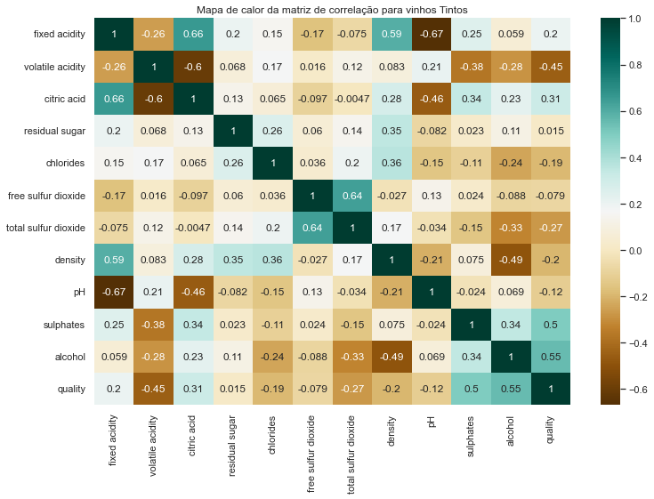

```python
# Matriz de correlação de vinhos tintos
fig, ax = plt.subplots(figsize=(12,8))
sns.heatmap(tintos_so.corr(), annot= True, cmap='BrBG').set_title("Mapa de calor da matriz de correlação para vinhos Tintos");
```

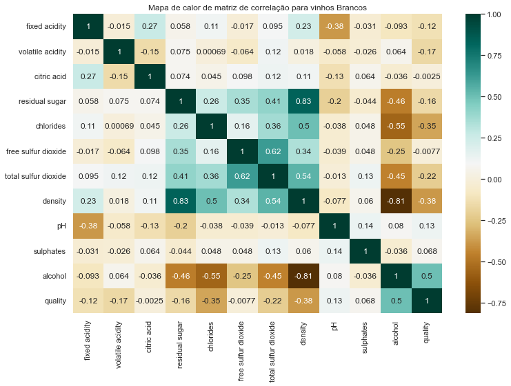

```python
# Matriz de correlação de vinhos brancos
fig, ax = plt.subplots(figsize=(12,8))
sns.heatmap(brancos_so.corr(), annot= True, cmap='BrBG').set_title("Mapa de calor de matriz de correlação para vinhos Brancos");
```

### Avaliação

Para os **vinhos tintos**, pode-se observar que a correlação é baixa e com pontos bem dispersos na maioria de pares de variáveis.  
No entanto, alguns pares de variávies apresentam indícios de correlação significante:

- Fixed acidity e citric acid (positiva)
- Fixed acidity e density (positiva)
- Fixed acidity e pH (negativa)
- Volatile acidity e citric acid (negativa)
- Citric acid e density (positiva)
- Citric acid e pH (negativa)
- Residual sugar e density (positiva)
- Free sulfur dioxide e total sulfur dioxide (positiva)
- Density e alcohol (negativa)

A avaliação vale também para os **vinhos brancos**, mas a correlação entre "volatile acidity" e "citric acid" e entre "citric acid" e "density" é menos intensa; ainda, existe uma correlação maior entre "total sulfur dioxide" e "density" para esse tipo de vinho.

# Etapa 2: Regressão Linear

```python
# Definição da função a utilizar para cada tipo de vinho

def linear_regression(X: "array_like", y_true: "array_like") -> dict:

    ''' Modela os dados de X através de uma regressão linear múltipla, retornando suas predições,
        bem como métricas de avalização através de um y_true passado como argumento '''

    # Intanciando o modelo e fazendo ajuste
    lr = LinearRegression()
    lr.fit(X=X, y=y_true)

    # Obtendo predições
    y_pred = lr.predict(X)

    # Avaliação
    mse = round(mean_squared_error(y_true=y_true, y_pred=y_pred), 3)
    r2 = round(r2_score(y_true=y_true, y_pred=y_pred), 3)

    return {'predicoes': y_pred, 'mse': mse, 'r2': r2, 'b0':lr.intercept_, 'b1':lr.coef_}

# Plota os gráficos scatter e histograma de resíduos
def plot_res_lr(y_pred: "array_like", y_true: "array_like", title: str) -> None:

    ''' Plota gráficos dos resultados da regressão linear múltipla com base nos valores preditos,
        valores reais e com um título passado como argumento '''
    # Inicialização do gráfico
    fig = make_subplots(rows=1, cols=2, subplot_titles = ['Predito vs real','Distribuição de Resíduos'],
                        horizontal_spacing=0.20)
    # Gráfico de predito vs. real
    fig.add_trace(go.Scatter(y=y_pred, x=y_true, mode='markers', name='y_pred'), row=1, col=1)
    # Gráfico de resíduos
    fig.add_trace(go.Scatter(y=y_true, x=y_true, name='truth'), row=1, col=1)
    fig.add_trace(go.Histogram(x=y_pred - y_true, name='residuals'), row=1, col=2)
    # Alterando rótulos
    fig.update_yaxes(title_text='y_pred', row=1, col=1)
    fig.update_xaxes(title_text='y_true', row=1, col=1)
    fig.update_yaxes(title_text='Frequência', row=1, col=2)
    fig.update_xaxes(title_text='y_pred - y_true', row=1, col=2)
    fig.update_layout(title=title)
#    fig.show()
    fig.show(renderer="png", height=1000, width=2000)
```

```python
# Obtendo um dicionário de predições, MSE e R² para cada uma das modelagens (vinhos brancos e tintos, com ou sem outliers)
lr_tintos     = linear_regression(X=tintos.iloc[:,:-1]    , y_true=tintos.iloc[:,-1])     # Tintos
lr_tintos_so  = linear_regression(X=tintos_so.iloc[:,:-1] , y_true=tintos_so.iloc[:,-1])  # Tintos sem outliers
lr_brancos    = linear_regression(X=brancos.iloc[:,:-1]   , y_true=brancos.iloc[:,-1])    # Brancos
lr_brancos_so = linear_regression(X=brancos_so.iloc[:,:-1], y_true=brancos_so.iloc[:,-1]) # Brancos sem outliers
```

```python
lr_tintos['predicoes']
```

```
array([5.03285045, 5.13787975, 5.20989474, ..., 5.94304255, 5.47075621,
       6.00819633])
```

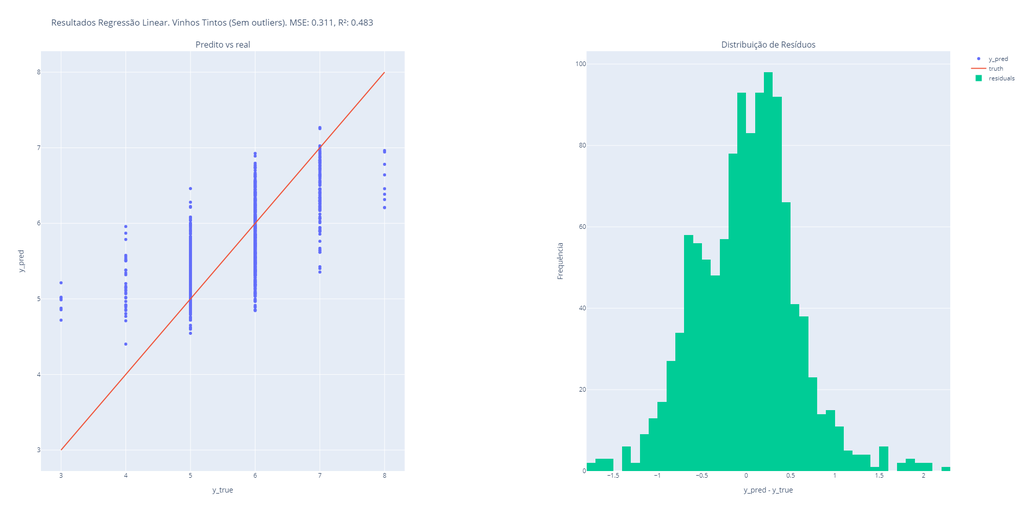

```python
plot_res_lr(y_true=tintos_so.iloc[:,-1], y_pred=lr_tintos_so['predicoes'],
            title='Resultados Regressão Linear. Vinhos Tintos (Sem outliers). MSE: {}, R²: {}'
            .format(lr_tintos_so['mse'], lr_tintos_so['r2']))
```

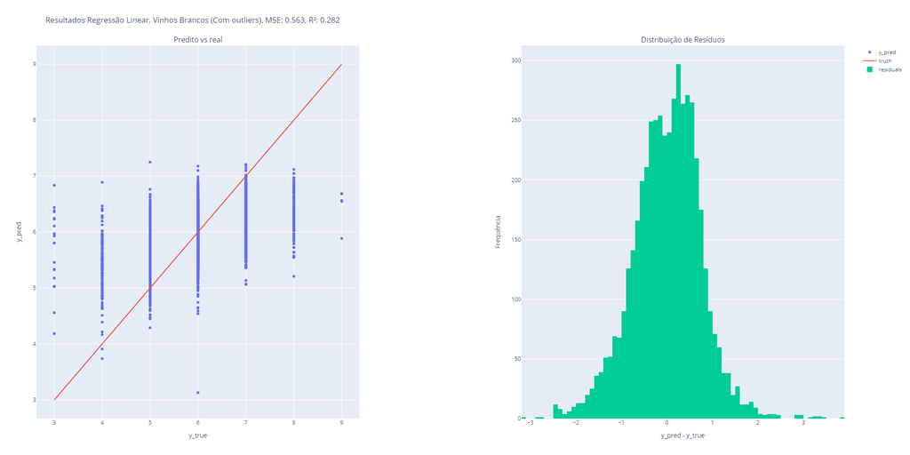

```python
plot_res_lr(y_true=brancos.iloc[:,-1], y_pred=lr_brancos['predicoes'],
            title= 'Resultados Regressão Linear. Vinhos Brancos (Com outliers). MSE: {}, R²: {}'
            .format(lr_brancos['mse'], lr_brancos['r2']))
```

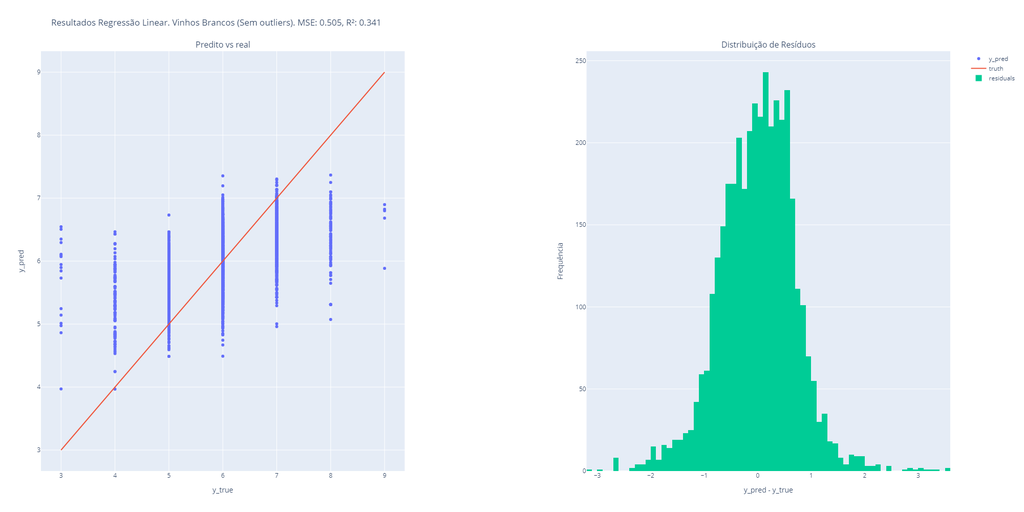

```python
plot_res_lr(y_true=brancos_so.iloc[:,-1], y_pred=lr_brancos_so['predicoes'],
            title= 'Resultados Regressão Linear. Vinhos Brancos (Sem outliers). MSE: {}, R²: {}'
            .format(lr_brancos_so['mse'], lr_brancos_so['r2']))
```

### Conclusões

Contudo, a precisão alcançada com essa técnica não é suficiente para definirmos o modelo como bom. Ele é apenas razoável.

# Etapa 3: Regressão Logística

- Remover *outliers* com fator fixo para todas as variávies;
- Remover *outliers* seletivamente, como feito com os *DataFrames* de valores absolutos.

  O intuito é comparar os resultados e a ecifácia do tratamento customizado de *outliers* proposto.

  Finalmente, o grupo optou por executar dois processos de regressão, para avaliar e optar pelo melhor:
- Regressão Logística Simples;
- Regressão Logística Train-Test.

```python
# Definindo Threshold do valor de Z para detecção uniforme de outliers para as diferentes variáveis
Z_THRESHOLD = 2.5
```

```python
# Função para obter um DataFrame ajustado (outliers são deslocados para os limites ao invés de serem removidos)
def trunc_z(z:float, threshold = Z_THRESHOLD) -> float:
    ''' Retorna o valor de z se o seu valor absoluto for menor ou igual que o threshold.
        Caso contrário, retorna o valor de threshold. '''
    if z > threshold:
        return threshold
    if z < -threshold:
        return -threshold
    return z
```

```python
# Inicializando instância de transformador de z-score da biblioteca sklearn
std_sct = StandardScaler()

# Aplicando a transformação e armazenando no dataframe tintos_zs
sc_varst = std_sct.fit_transform(tintos.iloc[:,:-1])
tintos_zs = pd.DataFrame(sc_varst, index=tintos.iloc[:,:-1].index, columns=tintos.iloc[:,:-1].columns)
tintos_zs.head(3)
```

|  | fixed acidity | volatile acidity | citric acid | residual sugar | chlorides | free sulfur dioxide | total sulfur dioxide | density | pH | sulphates | alcohol |
| --- | --- | --- | --- | --- | --- | --- | --- | --- | --- | --- | --- |
| 0 | -0.528360 | 0.961877 | -1.391472 | -0.453218 | -0.243707 | -0.466193 | -0.379133 | 0.558274 | 1.288643 | -0.579207 | -0.960246 |
| 1 | -0.298547 | 1.967442 | -1.391472 | 0.043416 | 0.223875 | 0.872638 | 0.624363 | 0.028261 | -0.719933 | 0.128950 | -0.584777 |
| 2 | -0.298547 | 1.297065 | -1.186070 | -0.169427 | 0.096353 | -0.083669 | 0.229047 | 0.134264 | -0.331177 | -0.048089 | -0.584777 |

```python
# Cálculo de outliers pelo método Z-score convencional (fator fixo para todas as variáveis)
outliers_tintos_zs = tintos_zs.loc[(abs(tintos_zs) > Z_THRESHOLD).any(axis=1)]
outliers_tintos_zs.head(3)
```

|  | fixed acidity | volatile acidity | citric acid | residual sugar | chlorides | free sulfur dioxide | total sulfur dioxide | density | pH | sulphates | alcohol |
| --- | --- | --- | --- | --- | --- | --- | --- | --- | --- | --- | --- |
| 9 | -0.470907 | -0.155419 | 0.457144 | 2.526589 | -0.349975 | 0.107592 | 1.688677 | 0.558274 | 0.251958 | 0.837107 | 0.072294 |
| 11 | -0.470907 | -0.155419 | 0.457144 | 2.526589 | -0.349975 | 0.107592 | 1.688677 | 0.558274 | 0.251958 | 0.837107 | 0.072294 |
| 13 | -0.298547 | 0.459094 | 0.097691 | -0.666062 | 0.563935 | -0.657454 | -0.531178 | 0.346269 | -0.331177 | 5.322101 | -1.241848 |

```python
# Dataframe com outliers removidos (variaveis com valores NORMALIZADOS)
tintos_zs_so = tintos_zs.drop(outliers_tintos_zs.index)
tintos_zs_so = tintos_zs_so.join(tintos.iloc[:,-1])   # Correção da coluna 'quality'
tintos_zs_so.head(3)
```

|  | fixed acidity | volatile acidity | citric acid | residual sugar | chlorides | free sulfur dioxide | total sulfur dioxide | density | pH | sulphates | alcohol | quality |
| --- | --- | --- | --- | --- | --- | --- | --- | --- | --- | --- | --- | --- |
| 0 | -0.528360 | 0.961877 | -1.391472 | -0.453218 | -0.243707 | -0.466193 | -0.379133 | 0.558274 | 1.288643 | -0.579207 | -0.960246 | 5 |
| 1 | -0.298547 | 1.967442 | -1.391472 | 0.043416 | 0.223875 | 0.872638 | 0.624363 | 0.028261 | -0.719933 | 0.128950 | -0.584777 | 5 |
| 2 | -0.298547 | 1.297065 | -1.186070 | -0.169427 | 0.096353 | -0.083669 | 0.229047 | 0.134264 | -0.331177 | -0.048089 | -0.584777 | 5 |

```python
# Dataframe com outliers removidos pelo processo de variáveis com fatores personalizados
tintos_sz_so2 = limpar(tintos_zs.join(tintos.iloc[:,-1]), 1)
tintos_sz_so2.head(3)
```

|  | fixed acidity | volatile acidity | citric acid | residual sugar | chlorides | free sulfur dioxide | total sulfur dioxide | density | pH | sulphates | alcohol | quality |
| --- | --- | --- | --- | --- | --- | --- | --- | --- | --- | --- | --- | --- |
| 0 | -0.528360 | 0.961877 | -1.391472 | -0.453218 | -0.243707 | -0.466193 | -0.379133 | 0.558274 | 1.288643 | -0.579207 | -0.960246 | 5 |
| 1 | -0.298547 | 1.967442 | -1.391472 | 0.043416 | 0.223875 | 0.872638 | 0.624363 | 0.028261 | -0.719933 | 0.128950 | -0.584777 | 5 |
| 2 | -0.298547 | 1.297065 | -1.186070 | -0.169427 | 0.096353 | -0.083669 | 0.229047 | 0.134264 | -0.331177 | -0.048089 | -0.584777 | 5 |

```python
# Obtenção de um DataFrame ajustado
tintos_zs_aj = tintos_zs.applymap(trunc_z)
tintos_zs_aj = tintos_zs_aj.join(tintos.iloc[:,-1])
tintos_zs_aj.head(3)
```

|  | fixed acidity | volatile acidity | citric acid | residual sugar | chlorides | free sulfur dioxide | total sulfur dioxide | density | pH | sulphates | alcohol | quality |
| --- | --- | --- | --- | --- | --- | --- | --- | --- | --- | --- | --- | --- |
| 0 | -0.528360 | 0.961877 | -1.391472 | -0.453218 | -0.243707 | -0.466193 | -0.379133 | 0.558274 | 1.288643 | -0.579207 | -0.960246 | 5 |
| 1 | -0.298547 | 1.967442 | -1.391472 | 0.043416 | 0.223875 | 0.872638 | 0.624363 | 0.028261 | -0.719933 | 0.128950 | -0.584777 | 5 |
| 2 | -0.298547 | 1.297065 | -1.186070 | -0.169427 | 0.096353 | -0.083669 | 0.229047 | 0.134264 | -0.331177 | -0.048089 | -0.584777 | 5 |

### Repetindo o processo para vinhos brancos

```python
# Inicializando instância de transformador de z-score da biblioteca sklearn
std_scb = StandardScaler()
# Aplicando a transformação e armazenando no dataframe brancos_zs
sc_varsb   = std_scb.fit_transform(brancos.iloc[:,:-1])
brancos_zs = pd.DataFrame(sc_varsb, index=brancos.iloc[:,:-1].index, columns=brancos.iloc[:,:-1].columns)
brancos_zs.head(3)
```

|  | fixed acidity | volatile acidity | citric acid | residual sugar | chlorides | free sulfur dioxide | total sulfur dioxide | density | pH | sulphates | alcohol |
| --- | --- | --- | --- | --- | --- | --- | --- | --- | --- | --- | --- |
| 0 | 0.172097 | -0.081770 | 0.213280 | 2.821349 | -0.035355 | 0.569932 | 0.744565 | 2.331512 | -1.246921 | -0.349184 | -1.393152 |
| 1 | -0.657501 | 0.215896 | 0.048001 | -0.944765 | 0.147747 | -1.253019 | -0.149685 | -0.009154 | 0.740029 | 0.001342 | -0.824276 |
| 2 | 1.475751 | 0.017452 | 0.543838 | 0.100282 | 0.193523 | -0.312141 | -0.973336 | 0.358665 | 0.475102 | -0.436816 | -0.336667 |

```python
outliers_brancos_zs = brancos_zs.loc[(abs(brancos_zs) > Z_THRESHOLD).any(axis=1)]
outliers_brancos_zs.head(3)
```

|  | fixed acidity | volatile acidity | citric acid | residual sugar | chlorides | free sulfur dioxide | total sulfur dioxide | density | pH | sulphates | alcohol |
| --- | --- | --- | --- | --- | --- | --- | --- | --- | --- | --- | --- |
| 0 | 0.172097 | -0.081770 | 0.213280 | 2.821349 | -0.035355 | 0.569932 | 0.744565 | 2.331512 | -1.246921 | -0.349184 | -1.393152 |
| 7 | 0.172097 | -0.081770 | 0.213280 | 2.821349 | -0.035355 | 0.569932 | 0.744565 | 2.331512 | -1.246921 | -0.349184 | -1.393152 |
| 14 | 1.712779 | 1.406558 | 2.361908 | 2.535440 | -0.264233 | 0.334712 | 0.791631 | 2.064007 | -1.379385 | 1.578709 | -0.661739 |

```python
# Dataframe com outliers removidos (variaveis com valores NORMALIZADOS)
brancos_zs_so = brancos_zs.drop(outliers_brancos_zs.index)
brancos_zs_so = brancos_zs_so.join(brancos.iloc[:,-1])
brancos_zs_so.head(3)
```

|  | fixed acidity | volatile acidity | citric acid | residual sugar | chlorides | free sulfur dioxide | total sulfur dioxide | density | pH | sulphates | alcohol | quality |
| --- | --- | --- | --- | --- | --- | --- | --- | --- | --- | --- | --- | --- |
| 1 | -0.657501 | 0.215896 | 0.048001 | -0.944765 | 0.147747 | -1.253019 | -0.149685 | -0.009154 | 0.740029 | 0.001342 | -0.824276 | 6 |
| 2 | 1.475751 | 0.017452 | 0.543838 | 0.100282 | 0.193523 | -0.312141 | -0.973336 | 0.358665 | 0.475102 | -0.436816 | -0.336667 | 6 |
| 3 | 0.409125 | -0.478657 | -0.117278 | 0.415768 | 0.559727 | 0.687541 | 1.121091 | 0.525855 | 0.011480 | -0.787342 | -0.499203 | 6 |

```python
# Dataframe com outliers removidos pelo processo de variáveis com fatores personalizados
brancos_sz_so2 = limpar(brancos_zs.join(brancos.iloc[:,-1]), 2)
brancos_sz_so2.head(3)
```

|  | fixed acidity | volatile acidity | citric acid | residual sugar | chlorides | free sulfur dioxide | total sulfur dioxide | density | pH | sulphates | alcohol | quality |
| --- | --- | --- | --- | --- | --- | --- | --- | --- | --- | --- | --- | --- |
| 0 | 0.172097 | -0.081770 | 0.213280 | 2.821349 | -0.035355 | 0.569932 | 0.744565 | 2.331512 | -1.246921 | -0.349184 | -1.393152 | 6 |
| 1 | -0.657501 | 0.215896 | 0.048001 | -0.944765 | 0.147747 | -1.253019 | -0.149685 | -0.009154 | 0.740029 | 0.001342 | -0.824276 | 6 |
| 2 | 1.475751 | 0.017452 | 0.543838 | 0.100282 | 0.193523 | -0.312141 | -0.973336 | 0.358665 | 0.475102 | -0.436816 | -0.336667 | 6 |

```python
brancos_zs_aj = brancos_zs.applymap(trunc_z)
brancos_zs_aj = brancos_zs_aj.join(brancos.iloc[:,-1])
brancos_zs_aj.head(3)
```

|  | fixed acidity | volatile acidity | citric acid | residual sugar | chlorides | free sulfur dioxide | total sulfur dioxide | density | pH | sulphates | alcohol | quality |
| --- | --- | --- | --- | --- | --- | --- | --- | --- | --- | --- | --- | --- |
| 0 | 0.172097 | -0.081770 | 0.213280 | 2.500000 | -0.035355 | 0.569932 | 0.744565 | 2.331512 | -1.246921 | -0.349184 | -1.393152 | 6 |
| 1 | -0.657501 | 0.215896 | 0.048001 | -0.944765 | 0.147747 | -1.253019 | -0.149685 | -0.009154 | 0.740029 | 0.001342 | -0.824276 | 6 |
| 2 | 1.475751 | 0.017452 | 0.543838 | 0.100282 | 0.193523 | -0.312141 | -0.973336 | 0.358665 | 0.475102 | -0.436816 | -0.336667 | 6 |

```python
# Definição da função de cálculo de Regressão Logística (RE) que será aplicada nos vários DataFrames

def reg_logistica(data, titulo):
    reg_log = LogisticRegression(penalty='none', max_iter=1000, random_state=0)

    # Definindo dominio e imagem para a modelagem
    X = data.iloc[:,:-1]
    y_true = data.iloc[:,-1].apply(lambda x: 1 if x >= 6 else 0) # Convertendo os valores do conjunto imagem

    # Ajuste (fit) e predições
    reg_log.fit(X=X, y=y_true)
    y_pred = reg_log.predict(X)

    # Valores resultantes
    cm        = confusion_matrix(y_true=y_true, y_pred=y_pred)
    acc       =   accuracy_score(y_true=y_true, y_pred=y_pred)
    precision =  precision_score(y_true=y_true, y_pred=y_pred)
    recall    =     recall_score(y_true=y_true, y_pred=y_pred)
    f1        =         f1_score(y_true=y_true, y_pred=y_pred)

    # Plotagem das matrizes de confusão com valores absolutos e percentuais

    titulo += " - Acc: {:.2f}% Prec: {:.2f}%".format(acc * 100, precision * 100)

    fig = make_subplots(rows=1, cols=2, horizontal_spacing = 0.10)

    # Ordenação dos eixos X e Y
    labels_x = np.sort(y_true.unique(),)[::-1]
    labels_y = np.sort(y_true.unique(),)

    # Matriz confusão com valores percentuais
    cm2 = np.round(cm / np.sum(cm) * 100, 2)

    # Formato do hover (nota que aparece ao mover o mouse sobre o gráfico)
    ht ='Predito: %{y}<br>Real: %{x}<br>Freq: %{z}<extra></extra>'

    fig.add_trace(go.Heatmap(z=cm, y=labels_y, x=labels_x, colorscale='Bluered',
                             reversescale=False, showscale=False, hovertemplate=ht), row=1, col=1)

    fig.add_trace(go.Heatmap(z=cm2, y=labels_y, x=labels_x, colorscale='Bluered',
                             reversescale=False, showscale=False, hovertemplate=ht), row=1, col=2)
    annot = []
    for i, row in enumerate(cm):
        for j, value in enumerate(row):
            annot.append({"x": labels_x[i], "y": labels_y[j], "font": {"color": "white"}, "text": str(value),
                          "xref": "x1", "yref": "y1", "showarrow": False})
    for i, row in enumerate(cm2):
        for j, value in enumerate(row):
            annot.append({"x": labels_x[i], "y": labels_y[j], "font": {"color": "white"}, "text": str(value),
                          "xref": "x2", "yref": "y2", "showarrow": False})

    fig.update_xaxes(title="Real"    , type='category')
    fig.update_yaxes(title="Predição", type='category')

    fig.update_layout(height=300, width=750, title='RE - (Abs/Perc) - ' + titulo, annotations = annot)
#    fig.show()
    fig.show(renderer="png", height=300, width=750)

    # Imprime os resultados abaixo do gráfico
    print('Accuracy: {:.2f}%, Precision: {:.2f}%, Recall: {:.2f}%, F1-score: {:.2f}%'
          .format(acc*100, precision*100, recall*100, f1*100))
```

```python
# Definição da função de cálculo de Regressão Logística Train-Test a ser aplicada aos diferentes DataFrames

def reg_log_ts(data, titulo):

    # Definindo dominio e imagem para a modelagem
    df = data.copy()
    df['result'] = df['quality'].apply(lambda x : 1 if x >= 6 else 0)
    Y = df['result']
    X = df.drop(labels=['quality','result'], axis=1)

    # Modelo Train-Test
    X_train, X_test, y_train, y_test = train_test_split(X, Y, test_size=0.11, random_state=0)

    # Ajuste (fit) e predições
    modelo = LogisticRegression()
    modelo.fit(X_train, y_train)
    y_pred = modelo.predict(X_test)

    # Valores resultantes
    cm        = confusion_matrix(y_true=y_test, y_pred=y_pred)
    acc       =   accuracy_score(y_true=y_test, y_pred=y_pred)
    precision =  precision_score(y_true=y_test, y_pred=y_pred)
    recall    =     recall_score(y_true=y_test, y_pred=y_pred)
    f1        =         f1_score(y_true=y_test, y_pred=y_pred)

    # Plotagem das matrizes de confusão com valores absolutos e percentuais

    titulo += " - Acc: {:.2f}% Prec: {:.2f}%".format(acc * 100, precision * 100)

    fig = make_subplots(rows=1, cols=2, horizontal_spacing = 0.10)

    # Ordenação dos eixos X e Y
    labels_x = np.sort(y_test.unique(),)[::-1]
    labels_y = np.sort(y_test.unique(),)

    # Matriz confusão com valores percentuais
    cm2 = np.round(cm / np.sum(cm) * 100, 2)

    # Formato do hover (nota que aparece ao mover o mouse sobre o gráfico)
    ht ='Predito: %{y}<br>Real: %{x}<br>Freq: %{z}<extra></extra>'

    fig.add_trace(go.Heatmap(z=cm, y=labels_y, x=labels_x,
                             colorscale=[[0,'rgb(16,200,32)'],[1,'rgb(200,32,16)']],
                             reversescale=False, showscale=False, hovertemplate=ht), row=1, col=1)

    fig.add_trace(go.Heatmap(z=cm2, y=labels_y, x=labels_x,
                             colorscale=[[0,'rgb(16,200,32)'],[1,'rgb(200,32,16)']],
                             reversescale=False, showscale=False, hovertemplate=ht), row=1, col=2)
    annot = []
    for i, row in enumerate(cm):
        for j, value in enumerate(row):
            annot.append({"x": labels_x[i], "y": labels_y[j], "font": {"color": "white"}, "text": str(value),
                          "xref": "x1", "yref": "y1", "showarrow": False})
    for i, row in enumerate(cm2):
        for j, value in enumerate(row):
            annot.append({"x": labels_x[i], "y": labels_y[j], "font": {"color": "white"}, "text": str(value),
                          "xref": "x2", "yref": "y2", "showarrow": False})

    fig.update_xaxes(title="Real"    , type='category')
    fig.update_yaxes(title="Predição", type='category')

    fig.update_layout(height=300, width=750, title='RE-Train/Test (Abs/Perc) - ' + titulo, annotations = annot)
#    fig.show()
    fig.show(renderer="png", height=300, width=750)

    # Imprime os resultados abaixo do gráfico
    print('Accuracy: {:.2f}%, Precision: {:.2f}%, Recall: {:.2f}%, F1-score: {:.2f}%'
          .format(acc*100, precision*100, recall*100, f1*100))
```

### Regressão Logística - Vinhos Tintos

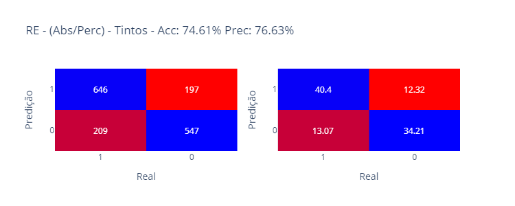

```
Accuracy: 74.61%, Precision: 76.63%, Recall: 75.56%, F1-score: 76.09%
```

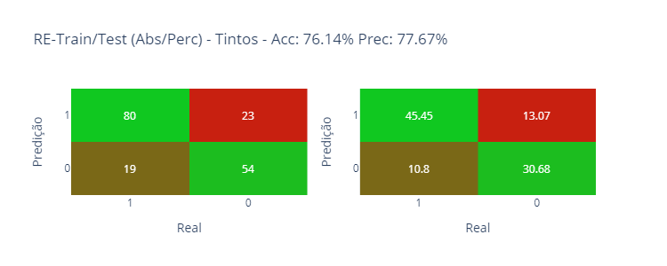

```
Accuracy: 76.14%, Precision: 77.67%, Recall: 80.81%, F1-score: 79.21%
```

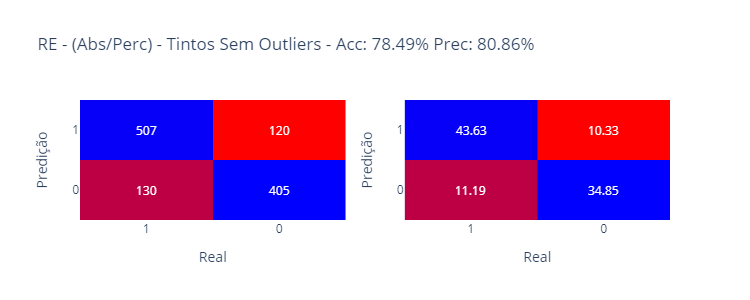

```
Accuracy: 78.49%, Precision: 80.86%, Recall: 79.59%, F1-score: 80.22%
```

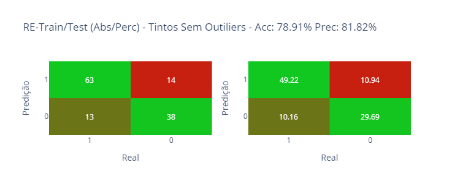

```
Accuracy: 78.91%, Precision: 81.82%, Recall: 82.89%, F1-score: 82.35%
```

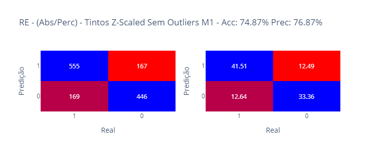

```
Accuracy: 74.87%, Precision: 76.87%, Recall: 76.66%, F1-score: 76.76%
```

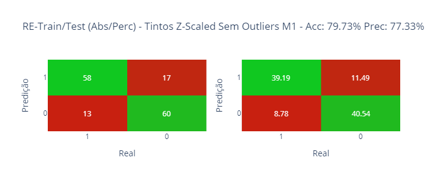

```
Accuracy: 79.73%, Precision: 77.33%, Recall: 81.69%, F1-score: 79.45%
```

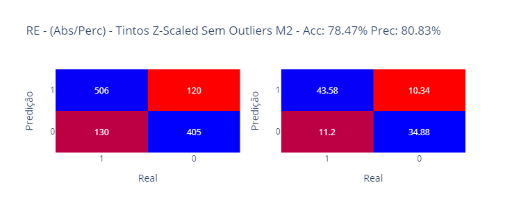

```
Accuracy: 78.47%, Precision: 80.83%, Recall: 79.56%, F1-score: 80.19%
```

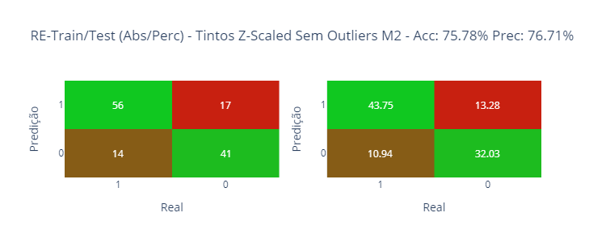

```
Accuracy: 75.78%, Precision: 76.71%, Recall: 80.00%, F1-score: 78.32%
```

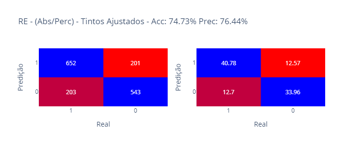

```
Accuracy: 74.73%, Precision: 76.44%, Recall: 76.26%, F1-score: 76.35%
```

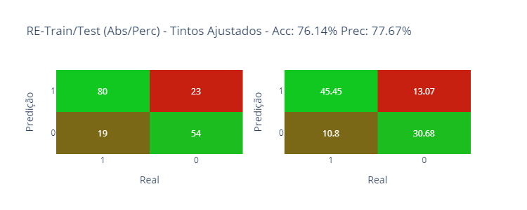

```
Accuracy: 76.14%, Precision: 77.67%, Recall: 80.81%, F1-score: 79.21%
```

```python
# Executa as duas regressões logísticas definidas
reg_logistica(tintos, "Tintos")
reg_log_ts(tintos, "Tintos")

reg_logistica(tintos_so, "Tintos Sem Outliers")
reg_log_ts(tintos_so, "Tintos Sem Outiliers")

reg_logistica(tintos_zs_so, "Tintos Z-Scaled Sem Outliers M1")
reg_log_ts(tintos_zs_so, "Tintos Z-Scaled Sem Outliers M1")

reg_logistica(tintos_sz_so2, "Tintos Z-Scaled Sem Outliers M2")
reg_log_ts(tintos_sz_so2, "Tintos Z-Scaled Sem Outliers M2")

reg_logistica(tintos_zs_aj, "Tintos Ajustados")
reg_log_ts(tintos_zs_aj, "Tintos Ajustados")
```

### Regressão Logística - Vinhos Brancos

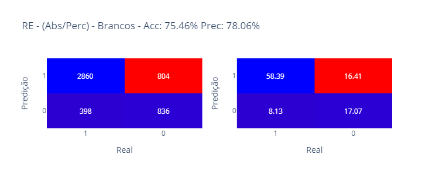

```
Accuracy: 75.46%, Precision: 78.06%, Recall: 87.78%, F1-score: 82.64%
```

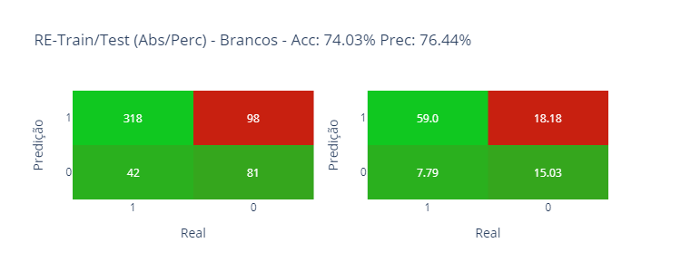

```
Accuracy: 74.03%, Precision: 76.44%, Recall: 88.33%, F1-score: 81.96%
```

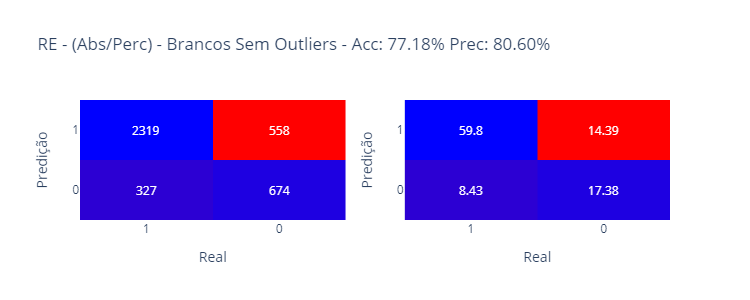

```
Accuracy: 77.18%, Precision: 80.60%, Recall: 87.64%, F1-score: 83.98%
```

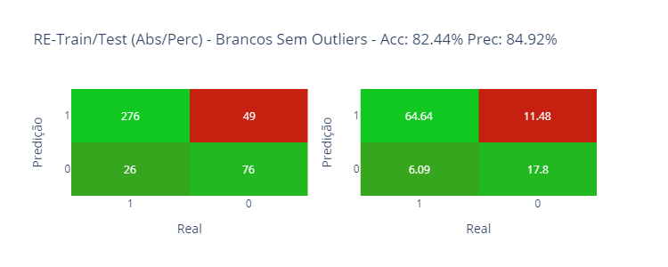

```
Accuracy: 82.44%, Precision: 84.92%, Recall: 91.39%, F1-score: 88.04%
```

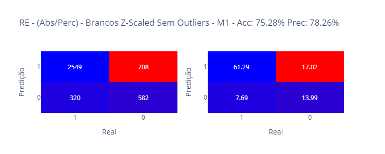

```
Accuracy: 75.28%, Precision: 78.26%, Recall: 88.85%, F1-score: 83.22%
```

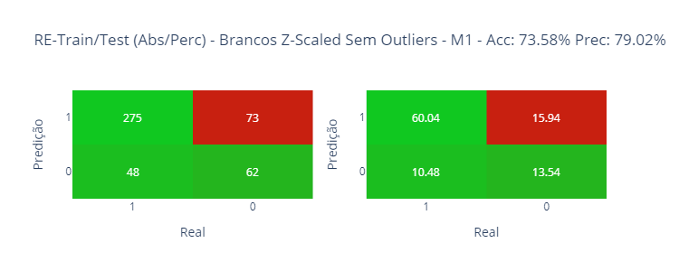

```
Accuracy: 73.58%, Precision: 79.02%, Recall: 85.14%, F1-score: 81.97%
```

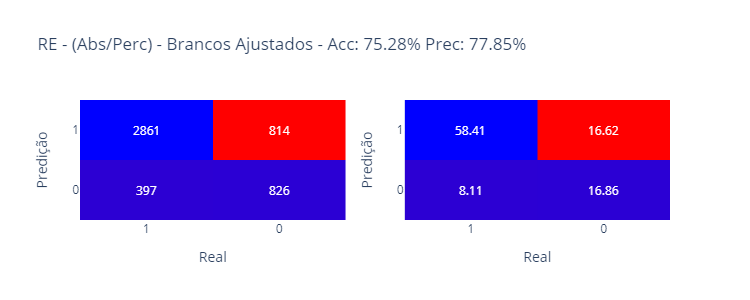

```
Accuracy: 75.28%, Precision: 77.85%, Recall: 87.81%, F1-score: 82.53%
```

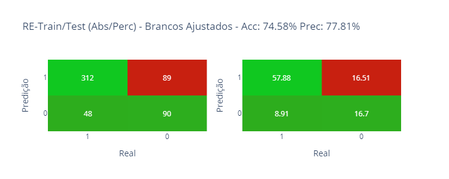

```
Accuracy: 74.58%, Precision: 77.81%, Recall: 86.67%, F1-score: 82.00%
```

```python
# Executa as duas regressões logísticas definidas

reg_logistica(brancos, "Brancos")
reg_log_ts(brancos, "Brancos")

reg_logistica(brancos_so, "Brancos Sem Outliers")
reg_log_ts(brancos_so, "Brancos Sem Outliers")

reg_logistica(brancos_zs_so, "Brancos Z-Scaled Sem Outliers - M1")
reg_log_ts(brancos_zs_so, "Brancos Z-Scaled Sem Outliers - M1")

reg_logistica(brancos_zs_aj, "Brancos Ajustados")
reg_log_ts(brancos_zs_aj, "Brancos Ajustados")
```

# Conclusão:

Os melhores modelos para vinhos tintos e brancos são aqueles baseados nos *DataFrames* de valores absolutos (não escalados em Z) com **remoção de *outliers* com fatores personalizados**, utilizados como entrada para a **regressão logística *train/test***.

Para Vinhos Tintos o modelo alcançou os seguintes resultados:  
**Accuracy: 78.91%, Precision: 81.82%, Recall: 82.89%, F1-score: 82.35%**